# Práctica 2.2: Explotación Paralelismo de Hilos

## Ejercicio 6: K-means

El K-Means es un algoritmo de aprendizaje no supervisado utilizado para la agrupación de datos en K clusters. Su objetivo es minimizar la suma de las distancias cuadradas entre los puntos de datos y el centroide más cercano.

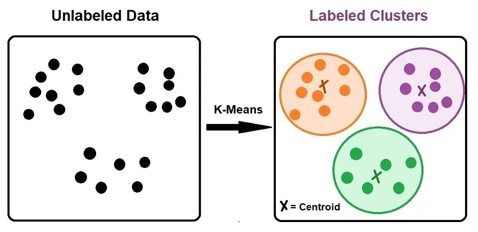

Algoritmo K-means

### ¿Como funciona el algoritmo?

1. *Inicialización*: Se eligen K centroides de manera aleatoria.
2. *Asignación del Clúster*: Cada punto se asigna al centroide más cercano.
3. *Reubicación de Centroides*: Se calculan los nuevos centroides como el promedio de los puntos asignados a cada cluster.
4. *Repetición*: Se repiten los pasos 2 y 3 hasta que los centroides no cambian significativamente (convergencia).

La implementación del algoritmo se realiza en el fichero **kmeans.cpp** donde la función `kmeans` es la encargada de realizar las etapas anteriormente mencionadas:

- La etapa de inicialización se realice en la función `initializeCentroid` donde se seleccionan como centroides algunos de los puntos del dataset almacenado en la estructura `data`
- La asignación de cluster se procesa en la función `assignCluster` donde se calcula las distancias euclídeas a los centroides y se queda con la distancia menor a todos los centroides
- La actualización de los centroides se realiza como la media de las posiciones asociadas a cada clase en la función `updateCentroid`

```c
void kmeans(std::vector<Point>& data, int k, int max_iters = 20000) {
    int dimensions = data[0].coords.size();
    std::vector<Centroid> centroids(k);
    initializeCentroids(centroids, data, k);

    for (int iter = 0; iter < max_iters; iter++) {
        assignClusters(data, centroids, k);

        std::vector<Centroid> newCentroids = centroids;
        updateCentroids(data, newCentroids, k, dimensions);

        centroids = newCentroids;
    }

    std::cout << "Final cluster centers:\n";
    for (int i = 0; i < k; i++) {
        std::cout << "Cluster " << i << ": (";
        for (size_t d = 0; d < centroids[i].coords.size(); d++) {
            std::cout << centroids[i].coords[d] << (d == centroids[i].coords.size() - 1 ? ")" : ", ");
        }
        std::cout << "\n";
    }
}
```

El contenido tanto de los puntos del dataset a entrenar como el de los centroides es una estructura con las coordenadas de cada punto N-dimensional y el tipo de cluster que viene descrito en el fichero *csv_dataset.h”:

```c
struct Point {
    std::vector<double> coords;
    int cluster;
};

struct Centroid {
    std::vector<double> coords;
};
```

### ToDo

- Realizar una implementación en OpenMP que explote el paralelismo TLP mediante hilos teniendo en cuenta:
  - La función `assignCluster` puede paralelizarse sencillamente ya que el cálculo de la distancia a los centroides y la selección del centroide más cercano es una tarea completamente independiente
  - La función `updateCentroids` puede también paralelizarse pero presenta un reto mayor: **existen varias reducciones** como el proceso en el array `count[cluster]`, o `sumCoords[cluster][d]`

# Herramienta de perfilado VTune

## Intel VTune

- Intel® VTune™ Profiler
- Como mejorar el rendimiento con varios análisis
  - Hotspots
  - Threading Efficiency
  - Microarchitecture
  - Memory Access
- Variables de entorno

```bash
user@lab:~ $ export ONEAPI_PATH=/opt/intel/oneapi/
user@lab:~ $ source $ONEAPI_PATH/vtune/latest/env/vars.sh
```

- La Herramienta Intel Vtune Amplier nos permite realizar un perfilado de la aplicación paralela para detectar posibles mejoras
  - Lanzamiento herramienta gráfica `amplxe-gui`, más moderno **`vtune-gui`**
  - Lanzamiento por línea de comandos `amplxe-cl`,más moderno **`vtune-collect`**

### 0.0.1 Comienzo Herramienta

[figure not shown]

Inicio VTune

1. Proyecto actual con el análisis de configuración (*New Project*)
2. Proyectos recientes
3. Resultados recientes
4. Recursos y documentación online
5. Artículos de y últimas noticias

## Opciones de análisis

- Hotspots
  - Utilización de CPU
- Memory Consumption:
  - Consumo de memoria (malloc-free) en cada rutina
- Microarchitecure Exploration:
  - Analiza cuellos de botella que afectan al rendimiento
  - Contadores HW
- Memory Access
  - Identifica los accesos a jerarquía memoria (NUMA, DRAM, L2…)
- Análisis
  - Más info [en web de Intel-VTune](https://software.intel.com/en-us/vtune) y [vídeo](https://www.intel.com/content/www/us/en/developer/videos/vtune-profiler-series.html)
  - A la hora de crear el proyecto con *New Project* seleccionar *Local Host* para analizar en el equipo local
    - Introducir el ejecutable (*path*) y primer análisis *Hotspots*

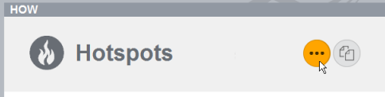

Análisis VTune

### Intel VTune: Análisis Hotspots

- *Hotspots* dirigido a la optimización de software y conocer dónde pasa tiempo la aplicación: **analizar la eficiencia**
- Incluye los análisis:
  - *Hotspots* para identificar las funciones más costosas y muestra la actividad de cada hilo
  - *Memory consuption* para analizar el consumo de memoria: caches y RAM

[figure not shown]

Análisis Hotspot

### Intel VTune: Parallelism Analysis

- Tipos de análisis para aplicaciones sensibles en cómputo: análisis general del rendimiento
- Incluye los análisis:
  - *Threading*: muestra balanceo de trabajo entre hilos y puntos de sincronización
  - *Compute-intensive Application*: caracterización rendimiento de HPC (punto flotante y la eficiencia de la memoria)

[figure not shown]

Análisis Paralelismo

### Intel VTune: Threading Efficiency

- Permite explorar
  - Wait Time: esperas prologadas por regiones de sincronización
  - Spin y Overhead Time: esperas y sobrecoste asociado al manejo de las regiones paralelas
  - Thread count: tiempo espera debido a sobresubscripción, espera a que los recursos compartidos estén disponibles cuando se ejecutan más hilos lógicos que cores físicos
- Problemas asociados al paralelismo
  - Asegurarse que se ejecutan todos los hilos disponibles
  - Problemas comunes a la concurrencia pueden identificarse
  - Análisis para detectar la contención en operaciones tipo Locks/Waits

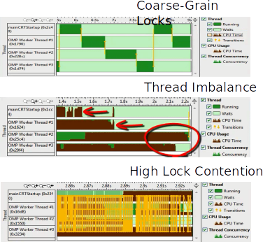

Eficiencia de Hilos

## Intel VTune: Threading Efficiency

- Demo:
  - Paralelización bucle **for**
  - schedules: static, dynamic, guided

[figure not shown]

[figure not shown]

Ejemplo Nbody-coulomb: dynamic

[figure not shown]

Ejemplo Nbody-coulomb: guided

### Intel VTune: Microachitecture

- **Microarchitecture analysis Group** introduce un tipo de análisis que ayuda a estimar los motivos de las ineficiencias en los procesadores modernos
  - *Microarchitecture Exploration* ayuda a identificar los problemas más comunes que afectan al rendimiento de la aplicación. Se puede considerar este análisis como punto de partida al análisis a nivel hw
  - *Memory Access* mide una serie de métricas para identificar accesos a los diferentes niveles de la jerarquía de memoria (como por ejemplo en arquitecturas NUMA)
- Una vez completado el análisis **Hotspots** para conocer ineficiencias en tu código…
  - Se recomienda efectuar el análisis *Microarchitecture Exploration analysis* para comprender como las ineficiencias se manifiestan en el uso del pipeline del core
  - VTune Profiler recolecta una lista complete de eventos hw
  - Calcula unas métricas predefinidas = identifica a nivel hw problemas asociados a ineficiencias

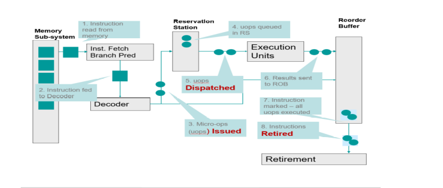

Flujo de Instrucciones

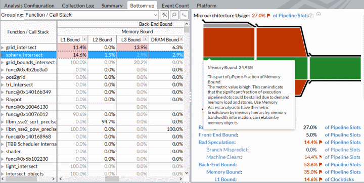

Análisis Microarquitectura